# =Analysis of Red Wines

Jon Baker

5/1/2021

### Getting Started

First I am going to install a few packages in the console, including ggplot2, knitr, gridextra, and dplyr. Next, let’s load them in! We will also load our redwine database.

### Loading Libraries and Setting Up the Database

```r
#Setting up libraries

library(ggplot2)
library(knitr)
library(dplyr)
library(gridExtra)
library(GGally)
#Next I am going to load the data

setwd('C:/Users/Home/Desktop/Project 4')
redwine <- read.csv('wineQualityReds.csv')
```

### Looking Over Some Summaries

Next I am going to get some summaries of the data. It looks like there are 13 variables to look at, with one of them being a primary key. We can look at some examples of the data using the STR command. The summary command is going to give us a look at the different quartiles of each variable in the data set. I notice that some variables operate on different orders of magnitude than others.

```r
names(redwine)
```

```
##  [1] "X"                    "fixed.acidity"        "volatile.acidity"
##  [4] "citric.acid"          "residual.sugar"       "chlorides"
##  [7] "free.sulfur.dioxide"  "total.sulfur.dioxide" "density"
## [10] "pH"                   "sulphates"            "alcohol"
## [13] "quality"
```

```r
str(redwine)
```

```
## 'data.frame':    1599 obs. of  13 variables:
##  $ X                   : int  1 2 3 4 5 6 7 8 9 10 ...
##  $ fixed.acidity       : num  7.4 7.8 7.8 11.2 7.4 7.4 7.9 7.3 7.8 7.5 ...
##  $ volatile.acidity    : num  0.7 0.88 0.76 0.28 0.7 0.66 0.6 0.65 0.58 0.5 ...
##  $ citric.acid         : num  0 0 0.04 0.56 0 0 0.06 0 0.02 0.36 ...
##  $ residual.sugar      : num  1.9 2.6 2.3 1.9 1.9 1.8 1.6 1.2 2 6.1 ...
##  $ chlorides           : num  0.076 0.098 0.092 0.075 0.076 0.075 0.069 0.065 0.073 0.071 ...
##  $ free.sulfur.dioxide : num  11 25 15 17 11 13 15 15 9 17 ...
##  $ total.sulfur.dioxide: num  34 67 54 60 34 40 59 21 18 102 ...
##  $ density             : num  0.998 0.997 0.997 0.998 0.998 ...
##  $ pH                  : num  3.51 3.2 3.26 3.16 3.51 3.51 3.3 3.39 3.36 3.35 ...
##  $ sulphates           : num  0.56 0.68 0.65 0.58 0.56 0.56 0.46 0.47 0.57 0.8 ...
##  $ alcohol             : num  9.4 9.8 9.8 9.8 9.4 9.4 9.4 10 9.5 10.5 ...
##  $ quality             : int  5 5 5 6 5 5 5 7 7 5 ...
```

```r
#Let's look at a summary of the different variables!

summary(redwine)
```

```
##        X          fixed.acidity   volatile.acidity  citric.acid
##  Min.   :   1.0   Min.   : 4.60   Min.   :0.1200   Min.   :0.000
##  1st Qu.: 400.5   1st Qu.: 7.10   1st Qu.:0.3900   1st Qu.:0.090
##  Median : 800.0   Median : 7.90   Median :0.5200   Median :0.260
##  Mean   : 800.0   Mean   : 8.32   Mean   :0.5278   Mean   :0.271
##  3rd Qu.:1199.5   3rd Qu.: 9.20   3rd Qu.:0.6400   3rd Qu.:0.420
##  Max.   :1599.0   Max.   :15.90   Max.   :1.5800   Max.   :1.000
##  residual.sugar     chlorides       free.sulfur.dioxide total.sulfur.dioxide
##  Min.   : 0.900   Min.   :0.01200   Min.   : 1.00       Min.   :  6.00
##  1st Qu.: 1.900   1st Qu.:0.07000   1st Qu.: 7.00       1st Qu.: 22.00
##  Median : 2.200   Median :0.07900   Median :14.00       Median : 38.00
##  Mean   : 2.539   Mean   :0.08747   Mean   :15.87       Mean   : 46.47
##  3rd Qu.: 2.600   3rd Qu.:0.09000   3rd Qu.:21.00       3rd Qu.: 62.00
##  Max.   :15.500   Max.   :0.61100   Max.   :72.00       Max.   :289.00
##     density             pH          sulphates         alcohol
##  Min.   :0.9901   Min.   :2.740   Min.   :0.3300   Min.   : 8.40
##  1st Qu.:0.9956   1st Qu.:3.210   1st Qu.:0.5500   1st Qu.: 9.50
##  Median :0.9968   Median :3.310   Median :0.6200   Median :10.20
##  Mean   :0.9967   Mean   :3.311   Mean   :0.6581   Mean   :10.42
##  3rd Qu.:0.9978   3rd Qu.:3.400   3rd Qu.:0.7300   3rd Qu.:11.10
##  Max.   :1.0037   Max.   :4.010   Max.   :2.0000   Max.   :14.90
##     quality
##  Min.   :3.000
##  1st Qu.:5.000
##  Median :6.000
##  Mean   :5.636
##  3rd Qu.:6.000
##  Max.   :8.000
```

### Reviewing the Data

I notice a primary key, a few different types of acid, as well as the values pH, alcohol, and density. These last three are variables that might be affected by others like the acids, and the acids might be correlated with one another somehow. There are other variables, like total sulfur dioxides and free sulfur dioxides. Could they be related to one another? Sugars, sulfates, quality and chlorides are also mentioned.

### Looking into Some Particular Variables

Let’s start by looking at the fixed acidity of the different red wines, just to get a feel for some of the data, and then move on to some other variables.

### Fixed Acidity of Red Wines

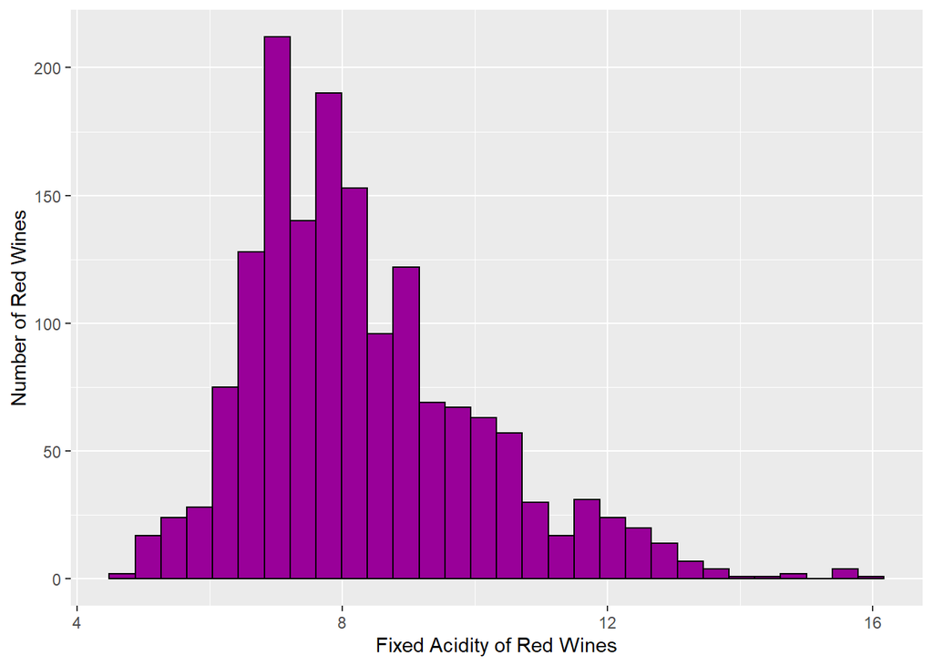

This graph looks fairly normal, it has a tail on the right. We could potentially eliminate outliers on the far-right on a graph like this.

### Looking at Everything

How about we take a look at all the variables? I am about to set up a ton of plots!

### Variability in Red Wines

```r
p1 <- qplot(x = fixed.acidity, data = redwine,
            xlab = 'Fixed Acidity of Red Wines',
            ylab = 'Number of Red Wines',
            color = I('black'), fill = I('#990099'))
p2 <- qplot(x = volatile.acidity, data = redwine,
            xlab = 'Volatile Acidity of Red Wines',
            ylab = 'Number of Red Wines',
            color = I('black'), fill = I('#990099'))
p3 <- qplot(x = citric.acid, data = redwine,
            xlab = 'Amount of Citric Acid in Red Wines',
            ylab = 'Number of Red Wines',
            color = I('black'), fill = I('#990099'))
p4 <- qplot(x = residual.sugar, data = redwine,
            xlab = 'Residual Sugar in Red Wines',
            ylab = 'Number of Red Wines',
            color = I('black'), fill = I('#990099'))
p5 <- qplot(x = chlorides, data = redwine,
            xlab = 'Chlorides in Red Wines',
            ylab = 'Number of Red Wines',
            color = I('black'), fill = I('#990099'))

p6 <- qplot(x = free.sulfur.dioxide, data = redwine,
            xlab = 'Free Sulfur Dioxide in Red Wines',
            ylab = 'Number of Red Wines',
            color = I('black'), fill = I('#990099'))

p7 <- qplot(x = total.sulfur.dioxide, data = redwine,
            xlab = 'Total Sulfur Dioxide in Red Wines',
            ylab = 'Number of Red Wines',
            color = I('black'), fill = I('#990099'))

p8 <- qplot(x = density, data = redwine,
            xlab = 'Density of Red Wines',
            ylab = 'Number of Red Wines',
            color = I('black'), fill = I('#990099'))

p9 <- qplot(x = pH, data = redwine,
            xlab = 'pH of Red Wines',
            ylab = 'Number of Red Wines',
            color = I('black'), fill = I('#990099'))
p10 <- qplot(x = sulphates, data = redwine,
             xlab = 'Sulphates in Red Wines',
             ylab = 'Number of Red Wines',
             color = I('black'), fill = I('#990099'))
p11 <- qplot(x = alcohol, data = redwine,
             xlab = 'Alcohol in Red Wines',
             ylab = 'Number of Red Wines',
             color = I('black'), fill = I('#990099'))
p12 <- qplot(x = quality, data = redwine,
             xlab = 'Quality of Red Wines',
             ylab = 'Number of Red Wines',
             color = I('black'), fill = I('#990099'))
```

### Variability of Data in Red Wines

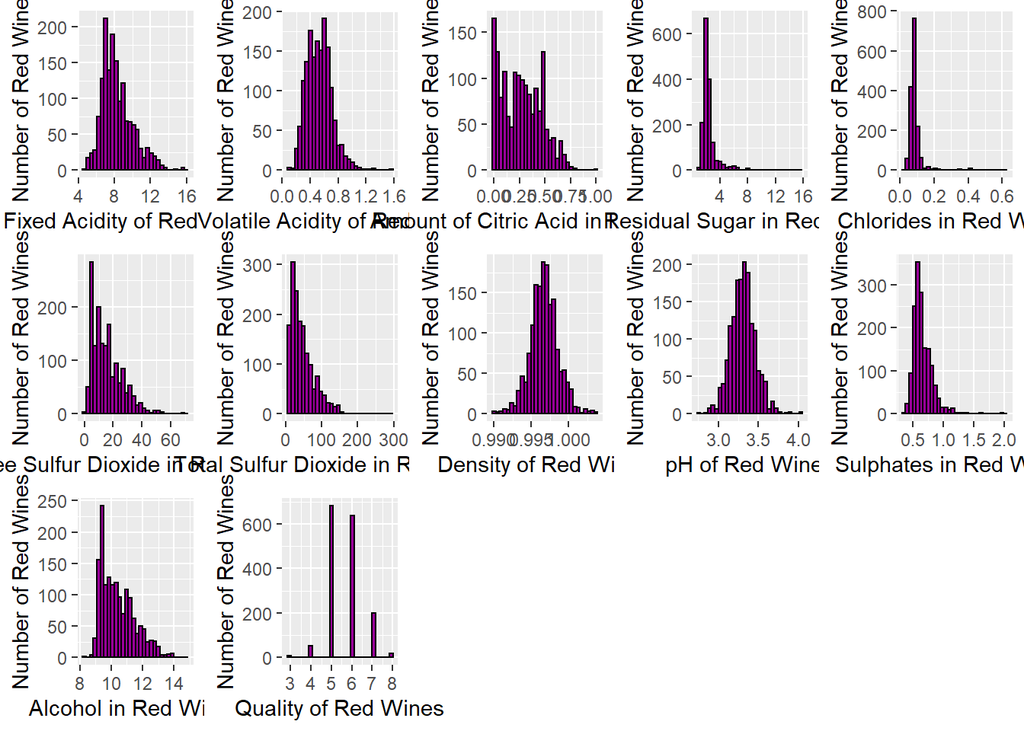

Density and pH seem the most normally distributed out of any of the graphs. Most of the graphs seem skewed to the right, with a large tail on the right-hand side.

It looks like there are some outliers in a few of the graphs, namely chlorides and residual sugar. Let us take a look at these and see about taking out the outliers.

### First Look at Residual Sugars in Red Wines

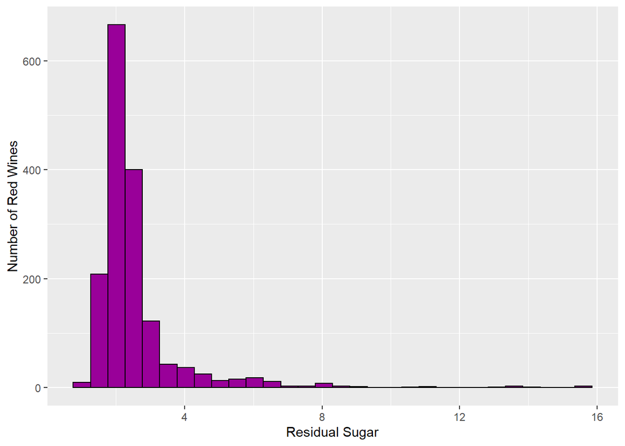

The residual sugar graph has a large tail to the right. This is one of the graphs I was interested in fixing up a bit. How about cutting this off around 6? Let us also try a binwidth of .25?

### A Second Look at Residual Sugars

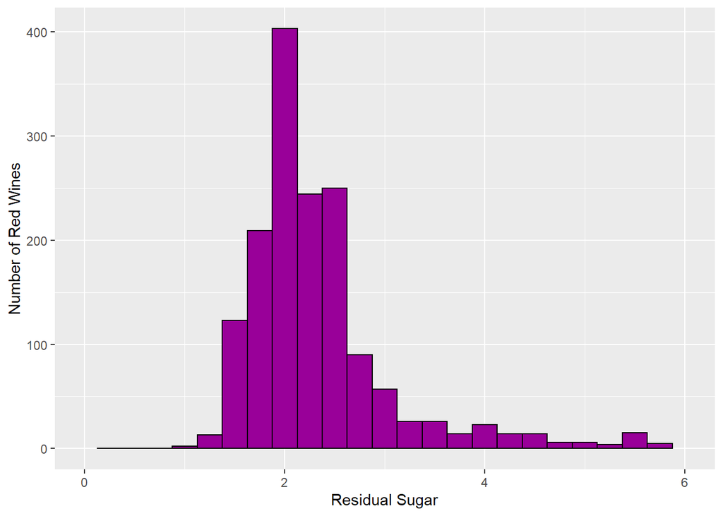

### A First Look at Chlorides in Red Wines

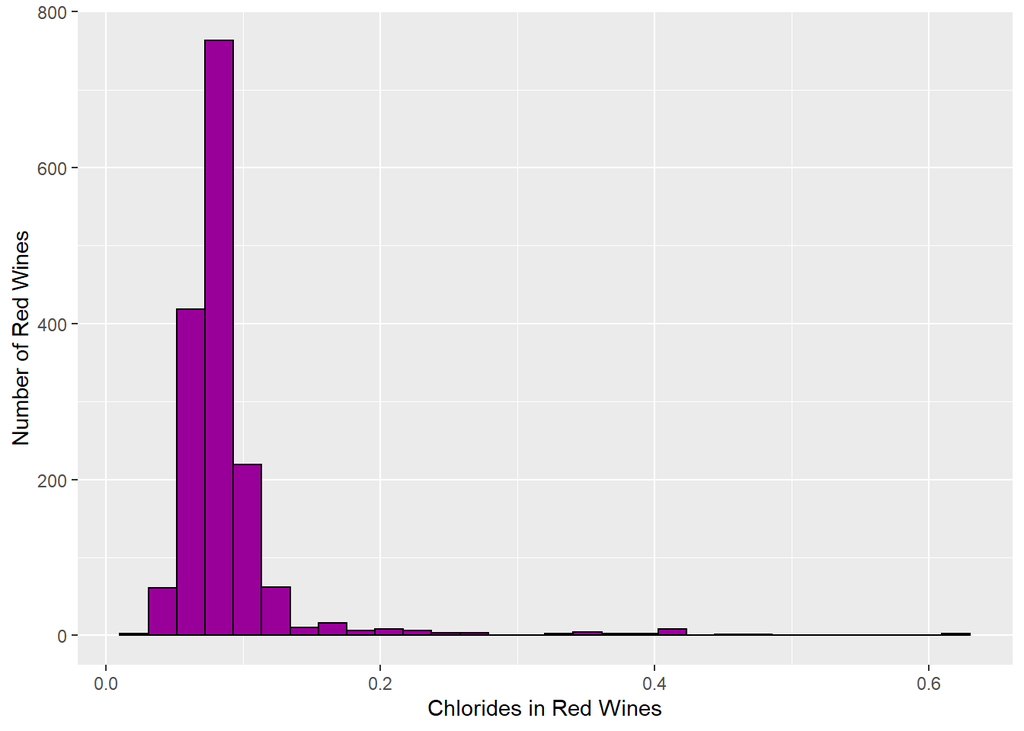

### A Second Look at Chlorides in Red Wines

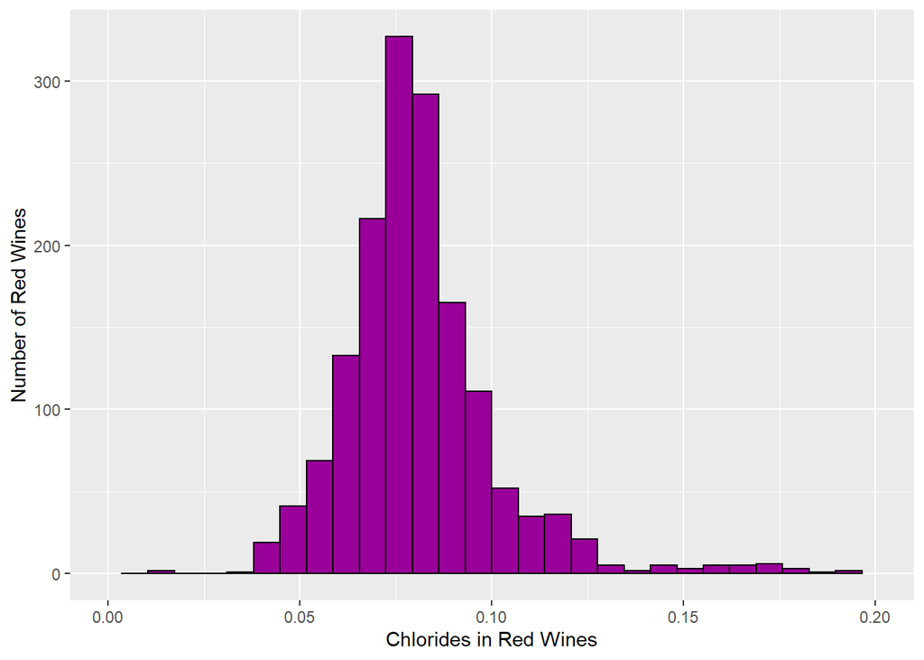

### Looking at Scatterplots

That’s great! Those graphs got cleaned up a bit. I wonder if we can create some scatterplots? Let’s look at correlation information first in order to most easily find interesting scatterplots.

### Correlations in Red Wines

```r
cor(redwine)
```

```
##                                 X fixed.acidity volatile.acidity citric.acid
## X                     1.000000000   -0.26848392     -0.008815099 -0.15355136
## fixed.acidity        -0.268483920    1.00000000     -0.256130895  0.67170343
## volatile.acidity     -0.008815099   -0.25613089      1.000000000 -0.55249568
## citric.acid          -0.153551355    0.67170343     -0.552495685  1.00000000
## residual.sugar       -0.031260835    0.11477672      0.001917882  0.14357716
## chlorides            -0.119868519    0.09370519      0.061297772  0.20382291
## free.sulfur.dioxide   0.090479643   -0.15379419     -0.010503827 -0.06097813
## total.sulfur.dioxide -0.117849669   -0.11318144      0.076470005  0.03553302
## density              -0.368372087    0.66804729      0.022026232  0.36494718
## pH                    0.136005328   -0.68297819      0.234937294 -0.54190414
## sulphates            -0.125306999    0.18300566     -0.260986685  0.31277004
## alcohol               0.245122841   -0.06166827     -0.202288027  0.10990325
## quality               0.066452608    0.12405165     -0.390557780  0.22637251
##                      residual.sugar    chlorides free.sulfur.dioxide
## X                      -0.031260835 -0.119868519         0.090479643
## fixed.acidity           0.114776724  0.093705186        -0.153794193
## volatile.acidity        0.001917882  0.061297772        -0.010503827
## citric.acid             0.143577162  0.203822914        -0.060978129
## residual.sugar          1.000000000  0.055609535         0.187048995
## chlorides               0.055609535  1.000000000         0.005562147
## free.sulfur.dioxide     0.187048995  0.005562147         1.000000000
## total.sulfur.dioxide    0.203027882  0.047400468         0.667666450
## density                 0.355283371  0.200632327        -0.021945831
## pH                     -0.085652422 -0.265026131         0.070377499
## sulphates               0.005527121  0.371260481         0.051657572
## alcohol                 0.042075437 -0.221140545        -0.069408354
## quality                 0.013731637 -0.128906560        -0.050656057
##                      total.sulfur.dioxide     density          pH    sulphates
## X                             -0.11784967 -0.36837209  0.13600533 -0.125306999
## fixed.acidity                 -0.11318144  0.66804729 -0.68297819  0.183005664
## volatile.acidity               0.07647000  0.02202623  0.23493729 -0.260986685
## citric.acid                    0.03553302  0.36494718 -0.54190414  0.312770044
## residual.sugar                 0.20302788  0.35528337 -0.08565242  0.005527121
## chlorides                      0.04740047  0.20063233 -0.26502613  0.371260481
## free.sulfur.dioxide            0.66766645 -0.02194583  0.07037750  0.051657572
## total.sulfur.dioxide           1.00000000  0.07126948 -0.06649456  0.042946836
## density                        0.07126948  1.00000000 -0.34169933  0.148506412
## pH                            -0.06649456 -0.34169933  1.00000000 -0.196647602
## sulphates                      0.04294684  0.14850641 -0.19664760  1.000000000
## alcohol                       -0.20565394 -0.49617977  0.20563251  0.093594750
## quality                       -0.18510029 -0.17491923 -0.05773139  0.251397079
##                          alcohol     quality
## X                     0.24512284  0.06645261
## fixed.acidity        -0.06166827  0.12405165
## volatile.acidity     -0.20228803 -0.39055778
## citric.acid           0.10990325  0.22637251
## residual.sugar        0.04207544  0.01373164
## chlorides            -0.22114054 -0.12890656
## free.sulfur.dioxide  -0.06940835 -0.05065606
## total.sulfur.dioxide -0.20565394 -0.18510029
## density              -0.49617977 -0.17491923
## pH                    0.20563251 -0.05773139
## sulphates             0.09359475  0.25139708
## alcohol               1.00000000  0.47616632
## quality               0.47616632  1.00000000
```

Fixed acidity vs citric acid, and fixed acidity vs density look interesting! Let’s check those out in greater detail.

### Fixed Acidity vs Citric Acid in Red Wines

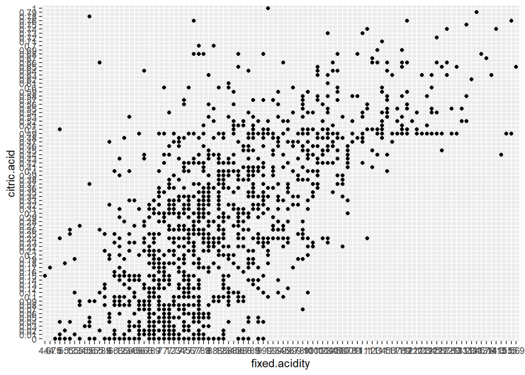

The data definitely looks correlated, in fact the correlation is around .6717, one of the highest in the data set. It would make sense that the amount of citric acid correlates with the amount of fixed acidity in a wine, as citric acid is a type of acid.

### Fixed Acidity vs Density in Red Wines

[figure not shown]

It looks as if there is a positive correlation between fixed acidity and density. Does this mean that the more acidic something is, the denser it is? Well, we do know that the correlation is around .6680.

Further exploration online found this study, and the data seems to show that the more acidic something is, the denser it is, although maybe this just goes for liquids soluable in water.

https://wissen.science-and-fun.de/chemistry/chemistry/density-tables/density-of-sulfuric-acid-and-sulfur-trioxide/

### pH and Density

[figure not shown]